# doi:10.1207/S15327663JCP1101_5

Converted from PDF `Laczniak-NegativeWOMAttribution-2001-JCP.pdf` · 17 pages · anchors: page `#pN`, block `#pN-bK`

Page 1

JOURNAL OF CONSUMER PSYCHOLOGY, **]](I),** 57-73 Copyright *O* 2001, Lawrence Erlbaum Associates, Inc.

## Consumers' Responses to Negative Word-of-Mouth Communication: An Attribution Theory Perspective

#### Russell N. Laczniak, Thomas E. DeCarlo, and Sridhar N. Ramaswami

Department of Marketing

Iowa State University

Research on negative word-of-mouth communication (WOMC) in general, and the process by which negative WOMC affects consumers' brand evaluations in particular, has been limited. This study uses attribution theory to explain consumers' responses to negative WOMC. Experi- mental results suggest that (a) causal attributions mediate the negative WOMC-brand evalua- tion relation, (b) receivers' attributions depend on the manner in which the negative WOMC is conveyed, and (c) brand name affects attributions. Results also suggest that when receivers at- tribute the negativity of the WOMC message to the brand, brand evaluations decrease; however, if receivers attribute the negativity to the communicator, brand evaluations increase.

Word-of-mouth communication (WOMC) is an important marketplace phenomenon by which consumers receive infor- mation relating to organizations and their offerings. Because WOMC usually occurs through sources that consumers view as being credible (e.g., peer reference groups; Brooks, 1957; Richins, 1983), it is thought to have a more powerful influ- ence on consumers' evaluations than information received through commercial sources (i.e., advertising and even neu- tral print sources such as Consumer Reports; Herr, Kardes, & Kim, 1991). In addition, this influence appears to be asyrn- metrical because previous research suggests that negative WOMC has a stronger influence on customers' brand evalua- tions than positive WOMC (Amdt, 1967; Mizerski, 1982; Wright, 1974). Given the strength of negative, as opposed to positive WOMC, the study presented here focuses on the for- mer type of information.

Our research develops and tests, using multiple studies, a set of hypotheses that describes consumers' attributional and evaluative responses to different types of negative-WOMC messages. The hypotheses posit that consumers will generate predictable patterns of attributional responses to nega- tive-WOMC messages that are systematically varied in terms of information content. Furthermore, they predict that attributional responses will mediate the negative WOMC-brand evaluation relation. Finally, and similar to re- cent studies (cf. Herr et al., 1991), the hypotheses suggest

Requests for reprints should be sent to Russell N. Laczniak, Iowa State University, Department of Marketing, 300 Carver Hall, Ames, IA 5001 1-2065. E-mail: LACZNIAK@IASTATE.EDU

consumer responses to negative WOMC are likely to be influenced by strength of the targeted brand's name.

This study extends research on negative WOMC in two important ways. First, whereas previous studies have typically examined receivers' responses to a summary statement of a fo- cal brand's performance (cf. Bone, 1995; Herr et al., 1991), it is likely that the information contained in negative-WOMC mes- sages is more complex than thls. In this study, focal messages are manipulated to include three components of information besides the communicator's summary evaluation (Richins,

1984). Messages include information about the (a) consensus of others' views of the brand (besides the communicator), (b) consistency of the communicator's experiences with the brand over time, and (c) distinctiveness of the communicator's opin- ions of the focal brand versus other brands in the category. In- terestingly, these types of information correspond to the information dimensions examined in Kelley's (1 967) seminal work dealing with attribution theory. It is also important to note that although others have used this work to model individual responses to another's actions (e.g., observing someone's in- ability to dance), this study is the first that empirically extends Kelley's research into a context in which consumers interpret a conversation about a brand.

Second, whereas other studies have posited the existence of a direct relation between negative WOMC and postexposure brand evaluations (e.g., Amdt, 1967; Haywood, 1989; Katz & Lazerfield, 1955; Morin, 1983), our investigation examines the attributional process that explains this association. This approach is consistent with the thinking of several researchers (i.e., Bone, 1995; Herr et al., 1991; Smith & Vogt, 1995) who posited that cognitive mechanisms

Page 2

are important, as they can more fully explain the negative WOMC-brand evaluation linkage. Furthermore, this re- search is consistent with other studies that suggest (but do not test the notion) that receivers' cognitive processing of nega- tive WOMC involves causal attributional reasoning (cf. Folkes, 1988; Mizerski, Golden, & Kernan, 1979).

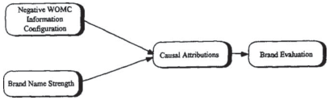

NOTE: figure/graphic rendered as an image from the PDF; its content is not machine-readable text. Caption (if any) follows as the next block.

#### **THEORY AND HYPOTHESES**

#### **Negative WOMC**

*Negative WOMC* is defined as interpersonal communication concerning a marketing organization or product that deni- grates the object of the communication (Richins, 1984; Weinberger, Allen, & Dillon, 1981). Negative WOMC po- tentially has a more powerful influence on consumer behav- ior than print sources, such as *Consumer Reports,* because in- dividuals find it to be more accessible and diagnostic (Herr et al., 1991). In fact, research has suggested that negative WOMC has the power to influence consumers' attitudes (Engel, Kegemeis, & Blackwell, 1969) and behaviors (e.g., Arndt, 1967; Haywood, 1989; Katz & Lazerfield, 1955).

#### **Attributions as Responses to Negative WOMC**

Because the transmission of negative WOMC involves interpersonal and informal processes, attribution theory appears to be particularly helpful in understanding a receiver's interpre- tation of a sender's motives for communicating such informa- tion (Hilton, 1995). The central theme underlying attribution theory is that causal analysis is inherent in an individual's need to understand social events, such as why another person would communicate negative information about a brand (Heider, 1958; Jones & Davis, 1965; Kelley, 1967). For this study, *causal attribution* is defined as the cognition a receiver generates to infer the cause of a communicator's generation of negative information (Calder & Burnkrant, 1977).

Figure 1 illustrates the proposed process consumers use to deal with negative WOMC. Specifically, it proposes two im- portant influences on receivers' attributional responses to negative-WOMC communication. First, the information con- veyed by the sender in a negative-WOMC message is posited to influence receivers' causal attributions. Second, brand-name strength of the focal brand is also thought to di- rectly affect receivers' causal attributions. These attributional responses, in turn, are expected to affect receivers' brand evaluations. Therefore, this study suggests that attributions mediate the presupposed negative-WOMC-brand evaluation relation. Such a model is consistent with theoretical frame- works of interpersonal communication that suggest that attri- butions mediate an interpersonal message's effect on a receiver's evaluation ofthe focal object (e.g., Hilton, 1995).

FIGURE **1** Attributional process model for receivers of negative word-of-mouth communication.

There is additional support for the mediational role played by attributions in influencing individuals' brand evaluations. For example, studies in the advertising literature have sug- gested that receivers generate causal attributions that in turn affect their evaluations of the advertised brand (e.g., Wiener & Mowen, 1986). In the performance evaluation literature, studies indicate that sales manager attributions of salesperson performance shape their reactions toward a salesperson (e.g., DeCarlo & Leigh, 1996). Thus, the following is proposed for receivers of negative WOMC:

HI: Causal attributions will mediate the effects of

negative WOMC on brand evaluations.

#### *Information Type and Causal Attributions*

According to research in classical attribution theory (Kelley, 1967, 1973), the categories of causal attributions that people generate in response to information include: stimulus (i.e., brand, in this case), person (i.e., communicator, in this case), circumstance, or a combination of these three.' The specific type of attributions generated by individuals, how- ever, depends on the manner in which information is con- veyed. According to attribution theory (Kelley, 1967) and other studies dealing with WOMC (e.g., Richins, 1984), a re- ceiver is likely to use three important information dimensions to generate causal attributions: consensus, distinctiveness, and consistency. In a negative-WOMC context, the consen- sus dimension refers to the degree to which others are likely to agree with the negative views of the communicator. The dis- tinctiveness dimension encapsulates the extent to which the communicator associates the negative information with a par- ticular brand but not other brands. Finally, the consistency di-

'Although attribution theo~y suggests that individuals have the potential to generate multiple and interactive attributional responses, this study fo- cuses only on those attributions that are thought to have a significant impact on brand evaluations in the negative-WOMC context (i.e., brand and com- municator attributions).

Page 3

**CONSUMERS' RESPONSES 59**

mension deals with the degree to which the communicator has had stable negative experiences with the brand across time and situations.

The three dimensions of information noted previously are typically viewed as being high or low in occurrence. For example, WOMC that is high on the consensus dimen- sion would suggest that others (beside the communicator) have had problems with the focal brand. Low-consensus information, on the other hand, would indicate that the communicator does not know anyone (besides him- or her- self) who has had problems with the focal brand. Com- bining the three information dimensions yields eight (2 x 2

**x** 2) potential configurations. It is commonly noted in attribution research (e.g., Hilton & Jaspars, 1987; Kelley,

1972; Teas & McElroy, 1986) that two (out of the eight possible) combinations provide theoretically unambigu- ous information (and thus are relevant to the study of nega- tive WOMC). These combinations are the high-consensus, high-distinctiveness, and high-consistency information configuration, as well as the low-consensus, low-distinc- tiveness, and high-consistency information configuration. **A** third combination-the low-consensus, high-distinc- tiveness, low-consistency information-has been posited to be the most ambiguous configuration (Hilton & Jaspars,

1987). Accordingly, the research presented here focuses on negative-WOMC messages utilizing these three infor- mation combinations.

Previous research has suggested that receivers will more likely attribute the consequences of an action (i.e., the negativity in a WOMC message) to the communication ob- ject (i.e., the focal brand) when information is configured as

being high consensus, high distinctiveness, and high consistency, in comparison to the other information configurations (Hilton & Jaspars, 1987; Kelley, 1967). Information con- tained in negative WOMC using this type of configuration will likely be viewed by receivers as more logical and well de- veloped than that configured as low consensus, low distinc- tiveness, and high consistency, or low consensus, high distinctiveness, and low consistency. Specifically, the infor- mation is considered to be logical because the communicator indicates that he or she has had repeated bad experiences with the focal brand (high consistency), knows of many others who have had problems with the focal brand (high consen- sus), and also believes that most other brands are of high qual- ity (high distinctiveness). After receiving such focused and cogent arguments, we believe that consumers will generate stronger brand attributions to it as compared to the other nega- tive-WOMC configurations.

Receivers of a low-consensus, low-distinctiveness, and high-consistency configuration, on the other hand, should be inclined to direct the negativity of the information toward the communicator for a number of reasons. Information config- ured in this manner is less logical and persuasive than WOMC configured as high consensus, distinctiveness, and consis- tency because it provides an inconsistent and critical view of

not just the focal brand, but all brands in the product class. Therefore, the communicator may be viewed as being overly negative and opens him- or herself to critical attributions. Furthermore, past research has indicated that individuals may consider a communicator's assessment **as** typical behavior in the absence of prior knowledge about the communicators' motives (Hilton, Smith, & Alicke, 1988). For negative WOMC configured as low consensus, low distinctiveness, and high consistency, the communicator's assessment may be perceived as containing more information about the com- municator than the focal brand of the conversation. Spe- cifically, the communicator bases the negative argument on his or her repeated bad experiences (high consistency), but when questioned, the communicator provides information that no one else he or she knows has had problems (low con-

sensus) and that he or she feels all brands are of low quality (low-distinctiveness information). Thus, the communicator is likely to be viewed as contradictory and the receiver should attribute the negativity toward the communicator.

This study utilizes negative WOMC configured as low consensus, high distinctiveness, and low consistency as a comparison to the other two scenarios for a number of rea- sons. First, there is significant evidence that this configura- tion is the most ambiguous with respect to brand and communicator attributions (cf. Hilton & Jaspars, 1987; Iacobucci & McGill, 1990). Second, research indicates that the perceived informativeness of this configuration about the focal object or Person is low (Hilton & Slugoski, 1986). Be- cause of this, we believe that the low-consensus, high-distinc- tiveness, low-consistency pattern is uniquely suited as a comparison configuration to the two patterns that yield unam- biguous attribution patterns.2 Thus, all hypothesized compar- isons of the strength of specific attributional responses made by receivers of the high-consensus, high-distinctiveness, and high-consistency scenario versus the low-consensus, low-distinctiveness, and high-consistency scenario are im- plicitly made in comparison to this configuration as well. Therefore, the following comparison hypotheses for the three negative-WOMC configurations are:

H2: Consumers exposed to negative WOMC config-

ured as high consensus, high distinctiveness, and high consistency will be more likely to attribute the negativity of the message toward the brand than those receiving other configurations.

H3: Consumers exposed to negative WOMC config-

ured **as** low consensus, low distinctiveness, and high consistency will be more likely to attribute the negativity of the message toward the commu- nicator than those receiving other configurations.

AS **will be seen in Study 2. we examine responses to alternative informa- tion configurations.**

Page 4

#### *Brand Name and Causal Attributions*

Prior research has suggested that the effects of negative WOMC on brand evaluations are likely to be reduced when prior positive brand impressions exist in consumers' memo- ries (Herr et al., 1991). Consistent with this notion, we con- tend that the effect of a brand name is likely to influence consumers' attributional processing of negative WOMC. **A** more-favorable brand name is expected to reduce the persua- siveness of negative WOMC because impression-inconsis- tent information is typically deflected away from the brand and discounted (Hoch & Deighton, 1989). Such a view is con- sistent with research in attribution theory, which suggests that attributions directed at the focal object are unlikely to be gen- erated by receivers who have favorable associations with it (Harvey & Weary, 1984). Thus, based on the cognitive pro- cess mechanisms of attributional biasing (De Nisi, Cafferty, & Meglino, 1984; Regan, Straus, & Fazio, 1974) and dis- counting (Sanbonmatsu, Kardes, & Gibson, 1989), receivers should attribute negativity away from the focal brand when the negative information (about the focal brand) is inconsis- tent with a positive brand name. On the other hand, negative WOMC is more likely to fit with consumers' associations for less-favorable brand names and should reinforce these asso- ciations (cf. Wilson & Peterson, 1989). Therefore, the follow- ing hypothesis is proposed:

H4: Consumers exposed to negative WOMC about a

more-favorable brand will be less likely to attribute the negativity toward the brand than those receiv- ing negative WOMC about a less-favorable brand.

However, if not toward the brand, to where (or to whom) do receivers of negative WOMC about more-favorable brands at- tribute the negativity? It is our contention that receivers of neg- ative information about favorable brands will be more likely to attribute the negativity of the WOMC toward the communica- tor. Hilton's (1 995) model of social communication suggested that, all things being equal, a receiver assumes that a conveyor of interpersonal information is trying to be helpful and conse- quently should be positively disposed toward the communica- tor at the time of exposure. However, when contradictory information (i.e., negative information about a favorable brand name) is presented by a communicator, the receiver will shift his or her impressions toward the negative, leaving him or her in a state ofcognitive imbalance. Hilton's model suggested this imbalance will be overcome by the receiver's attributing the negativity of the message toward the communicator. Thus, we posit the following:

H5: Consumers exposed to negative WOMC about

a more-favorable brand will be more likely to attribute the negativity toward the communica- tor than those receiving negative WOMC about a less-favorable brand.

#### *Attributions and Brand Evaluation*

The influential role of brand attributions on brand evaluation is consistent with cognitive processing models of perfor- mance evaluation (e.g., DeCarlo & Leigh, 1996; De Nisi et al., 1984). In these models, there is a direct linkage between performance attributions of an employee and his or her per- formance evaluation. In other words, when supervisors attrib- ute negative performance to the subordinate, evaluations tend to be lower. Extending this notion to the negative-WOMC context, we posit that brand attributions will have a negative effect on brand evaluations. This is the case because as re- ceivers link the negativity of WOMC messages to a brand (via brand attributions), their evaluations should be negatively af- fected. Specifically, we hypothesize the following:

H6: The strength of brand attributions generated in

response to negative WOMC about a particular brand will be inversely related to brand attitudes.

We hypothesized that communicator attributions will be directly related to brand evaluations (i.e., apositive relation is expected between communicator attributions and brand eval- uations). This view is consistent with theories of conversation that suggest that the interpretation of social discourse requires a form of cognitive balancing (cf. Brown & van Kleeck,

1989). In the process of communicatingnegative WOMC, the communicator is establishing a negative link between them- selves and the brand (in the eyes of the receiver). When the re- ceiver attributes negativity toward the communicator, his or her reasoning process will allow him or her to disassociate it from the brand. Once blame is assessed toward the communi- cator, Hilton (1995) suggested that the receiver will rally to the defense of the brand and in fact be more supportive of it. Thus, it is hypothesized that:

H7: The strength of communicator attributions gener-

ated in response to negative WOMC about a particular brand will be directly related to brand attitudes.

#### **STUDY 1**

#### **Method**

Participants were randomly assigned to one of six cells in a **3** (negative-WOMC information scenario) x 2 (brand-name strength) full-factorial experiment. The negative-WOMC message was manipulated to provide three information con- figurations, as noted previously. Strength of brand name was manipulated by providing negative WOMC about more- ver- sus less-favorable brands. Dependent measures included multi-item measures of causal attributions (i.e., measures of

Page 5

**CONSUMERS' RESPONSES 61**

the strength of brand and communicator attributions) and postexposure brand evaluations. Several manipulation checks were also obtained.

*Stimuli*

*Product.* Personal computer (or PC) brands were featured as the experimental stimuli for a number of reasons. First, previous research has indicated that there must be sufficient motivation for consumers to generate and receive negfitive WOMC (Richins, 1984). Because personal computers are complex and relatively expensive products, there is a reason- ably high probability that consumers may be involved with the product class and thus be motivated to attend to and process negative WOMC about brands within the product class. Sec- ond, we believe that both high- and low-product knowledge in- dividuals use personal computers; thus, even low-knowledge people might engage in negative WOMC.3 Finally, personal computers have been used as experimental stimuli in similar negative-WOMC studies (Herr et al., 1991). The potential ef- fects of product involvement and product knowledge are as- sessed by including them as covariates in the study.

*Brand-name strength.* The starting point for selecting brands that differed in name strength was to use the results of a study sponsored by the *Wall Street Journal* (Pope, 1993) in the personal computer category. According to the results of this study, the brands Packard Bell and Everex ranked 9th and

loth, respectively, whereas IBM and Compaq were 1st and 2nd, respectively. Thus, two less-positive brand names (Packard Bell and Everex) and two more-positive brand names (IBM and Compaq) were pretested.

A number of brand-name strength measures were used in preexperimental pilot tests and the main experiments as ma- nipulation checks. The measures included scales of brand fa- miliarity, brand affect, brand awareness, favorable brand associations, and purchase intention. These measures were used in previous empirical research dealing with brand equity (Cobb-Walgren, Ruble, & Donthu, 1995). Pilot test results in- dicated that participants rated the Packard Bell and Everex computers significantly lower on these dimensions than IBM and Compaq computers. Furthermore, no significant differ-

**30ur sample indicated having a high degree of involvement with the per- sonal computer product class. Product class involvement was assessed with Zaichkowsky's (1985) scale. Factor analysis results suggest that this scale contained two dimensions: one appearing to be a utilitarian involvement fac- tor (a** = **.78) and the other as an aesthetic involvement factor (a** = **.91). Partic- ipants' mean level of utilitarian involvement is 6.1 1 on a 7-point scale, rang- ing from 1 (low involvement) to 7 (high involvement), and the mean level of aesthetic involvement is 5.37 on a similar 7-point scale-well above the mid- points of each scale. In addition, the sample reported having a moderate level ofpersonal computer knowledge (M= 6.07, SD** = **3.21), with 10 being a per- fect score. Personal computer knowledge was assessed with a 10-item objec- tive measure developed by the authors (KR-20** = **.91).**

ences were found between the two less-positive brand names (i.e., Packard Bell and Everex). However, the within-cell analysis for the more-positive brand-name computers indi- cates a significant difference between IBM and Compaq. IBM was rated more positive in our pilot tests than Compaq. However, we selected the more moderately rated Compaq brand name for use in the main experiments. We believed that using Compaq (vs. IBM) would be a stronger test of the power of brand name in consumers' processing of negative WOMC. Specifically, if differences are noted between Everex and Compaq brands in the main experiment, it would seem logical to conclude that the difference between Everex and IBM would be greater.

*Negative- WOMC scenarios.* Three distinct negative-WOMC conditions were developed using high and low levels of consensus, distinctiveness, and consistency infor- mation, as previously discussed. These configurations were: (a) high consensus, distinctiveness, and consistency; (b) low consensus, low distinctiveness, and high consistency; and (c) low consensus, high distinctiveness, low consistency.

Each negative-WOMC scenario contained identical information with the exception of the statements of either high or low levels of consensus, consistency, and distinctiveness in- formation, and the brand described in the scenario. Care was taken to ensure that relatively equal total word counts (high consensus, distinctiveness, and consistency = 208; low con- sensus, low distinctiveness, and high consistency = 210; and low consensus, high distinctiveness, low consistency = 206) were used for each scenario.

The negative-WOMC stimulus was a tape-recorded conversation that occurred between two confederates. The con- federates read the scenarios from a script provided by the authors. To ensure that the WOMC sounded natural, the con- federates rehearsed the script a number of times. The confed- erates included a man (Pat), a perceived computer expert and the provider of the negative comments, and a woman (un- named), the person interested in the other's opinion. (A tran- script of each scenario is provided in the Appendix.)

Participants

A total of 192 male and female undergraduate students was recruited from various business classes at a major midwestem university. Participants received extra course credit for their participation in the study. Because of missing data, 1 1 partici- pants were dropped from the analysis phase of the study. Thus, the final sample size was 18 1 (103 men and 78 women). The sample distribution across the six experimental cells ranged from a low of 26 (14%) to a high of 35 (19%) partici- pants. The use of a homogeneous sampling frame (e.g., un- dergraduate students) is appropriate as recommended theory test procedures require selection of respondent groups such that rigorous examinations can be conducted (Calder, Phil- lips, & Tybout, 1982).

Page 6

#### **Procedure**

Participants were randomly assigned to one of the six experimental cells. They were handed a booklet containing instruc- tions, a transcript of the negative WOMC, and related ques- tionnaire items. The first page of the booklet contained instructions that were read aloud by a proctor who invited the participants to read along. This procedure was used to increase participants' involvement with the conversation that is likely to occur in face-to-face conversations. The instructions read:

The University Microcomputer Products Center and Marketing Department have been gathering informa- tion from focus groups to determine what students look for in computers. These focus groups are routinely taped to capture as much information as possible. One session included an interesting conversation that oc- curred between two students during a session break. Because the conversation took place during a break, the quality of the tape was poor. So, you are going to listen to a reenacted audio tape of this conversation.

PLEASE LISTEN TO THIS CONVERSATION VERY CAREFULLY. While listening to this tape, keep in mind that we will be asking you to make judg- ments regarding the brand that these two people are talking about, the people who are having the conversa- tion, and the situation that surrounds this conversation. So, please follow this conversation carefully, because we will be asking you your opinions about the brand, the people, and the situation. A transcript of this con- versation has been provided. This may help you more closely follow the conversation.

Although the experimental procedure used in this study did not allow participants to hear face-to-face negative com- ments about the experimental brands as was the case in previ- ous studies (cf. Herr et al., 1991), it did allow the experimenters to achieve greater control of message content. Given that the focus of this study was to determine consum- ers' attributional and attitudinal responses to a variety of mes- sages (and not on the accessibility of the message compared to memory information), we concluded that the tradeoff be- tween the realism associated with a face-to-face message, versus a tape-recorded one with greater message content con- trol, was appropriate.

The second page of the booklet contained the transcript of the assigned negative-WOMC scenario. To ensure that partici- pants were actively involved in the experiment, they were told to read the transcript while listening to the taped conversation. Immediately following the conclusion of the tape, participants were asked to **turn** the page and read general questionnaire in- structions. The participants were then instructed to turn the page to the scaled causal attribution measures and read them prior to completing the scales. These instructions read:

Pat made some negative comments about (brand name inserted). There may be many reasons why he did so, but what we are interested in is your thoughts about why you think Pat made these comments. There are no right or wrong reasons, we simply want to find out your feelings for the statements below. You may refer back to the transcript on page 2 to help you respond.

Following these instructions, participants answered questions regarding their evaluation of the scaled attributions, brand evaluation, and questions related to the effectiveness of the manipulations.

Three separate manipulation-check groups (comprised of participants similar to those used in the main experiments) were used to test the efficacy of the brand-name manipula- tions and to check perceptions that each negative-WOMC scenario included consensus, consistency, and distinctive- ness information dimensions. In the first group, participants (n = 79) were given the brand-name manipulation check mea- sures for familiarity and affect for each brand, as well as mea- sures of brand evaluation. For the second pilot test, participants (n = 129) were provided with questionnaires that included four additional measures of brand-name strength: brand awareness, ad awareness, brand associations, and pur- chase intention (Cobb-Walgren et al., 1995). Participants completed these questionnaires for either the Compaq (n = 65) or Everex brands (n = 64). The third group (n = 68) lis- tened to the negative WOMC for the Compaq brand, and then they were asked to complete the manipulation check for the consensus, consistency, and distinctiveness information in the negative-WOMC scenarios.

#### **Measures**

*Causal Attributions*

Multi-item scales were developed to assess communicator and brand attributions for the cause of the negative information conveyed in the scenarios. The two measures were based on recommendations made by Lichtenstein and Bearden (1986) and Weiner (1980). In addition, the scale-development proce- dure used followed Churchill's (1979) paradigmatic recom- mendations. First, a large pool of items was developed to correspond to the brand and communicator attribution con- structs. To capture the richness of possible attributions, a num- ber of theoretical perspectives from the literature were utilized. Communicator attributions were developed from Wind's (1978) categories of people, which included demographic-so- cioeconomic factors, personality-lifestyle factors, and atti- tudes-behaviors toward a product. Brand attributions were developed with the aid of Enis and Roering's (1980) levels of product offerings. Two pilot tests (the first with n = 50 and the second with n = 44) were then conducted to purify the mea- sures. As a result of the tests and pretest, participants' re- sponses to open-ended questions in test scenarios-several

Page 7

CONSUMERS' RESPONSES 63

items (from each measureFwere eliminated, and others were revised to improve their specificity and precision.

For the final measures, in which we used ?-point scales ranging from 1 (strongly agree) to 7 (strongly disagree), ex- ploratory factor analysis of the nine causal attribution items yielded two factors accounting for 84% of the variance. The lowest item loading was .63. Inter-item correlations ranged from .66 to .9 1. The following header was used in measuring all causal attributions: "Pat said these negative things about - [insert brand name] because." The following specific items were used to measure brand attributions: "This PC is an inferior product," "This PC is an unpopular brand," "This PC's performance was poor," "This PC is unusual," and "This PC lacked the features Pat wanted or needed." The fol- lowing specific items were used to measure communicator at- tributions: "He doesn't know enough about using PCs," "He does not appear to have the expertise to evaluate the product properly," "He wanted to look smarter than he really is," and "He's the type of person who always says bad things about brands." For the two scales, a = .95 (brand attributions) and *a* = 95 (communicator attributions).

*Attitude Toward the Brand*

Three bipolar brand-attitude items on a 7-point scale, ranging from 1 (bad, unfavorable, negative) to 7 (good, favorable, posi- tive), were summed to form the postexposure brand evaluation measure (Ajzen & Fishbein, 1980). Factor analysis of these items yielded one factor explaining 91% of the variance. Loadings ranged from .92 to .95, and inter-item correlations ranged fiom .88 to .93. For the brand evaluation measure, *a* = .95 @gher strength brand name) and a = .93 (lower strength brand name).

*Manipulation Checks*

Multiple items were used to ensure that the brand-name treatments provided participants with stimuli that varied in their degree of perceived strength. Measures were developed to tap the brand familiarity and affect dimensions of brand name. Factor analysis on items corresponding to both dimen- sions yielded a two-factor solution with expected item load- ings. Specific items for the affect dimension of the brand scale include: "My overall opinion about this brand of com- puter is very favorable," "I have positive feelings about this brand," "I really like this brand of computer," and "Using this brand of computer makes me feel good about myself." Items

for the familiarity dimension of the brand equity scale include: "If I had to name a single brand to represent all comput- ers, it would be this one," "When I think of computers, this is the brand that comes to mind," and "This brand is a very good example of my image of what a computer is." The internal consistency of the two measures (i.e., familiarity and affect) was in the range of 0.68 and 0.79.

The measures of brand awareness, ad awareness, brand associations, and purchase intention used in the post hoc test

were similar to those employed by Cobb-Walgren et al. (1995). Specifically, brand awareness and ad awareness ("Have you heard of computers?'and "Have you ever seen any ad- vertising for -?') were assessed with one-item, 3-point scales ranging from 1 (yes), 2 (no), to 3 (don 't know). Brand as- sociations were obtained by asking participants the following question: "When you think o f computers, what descrip- tive words, thoughts, symbols, or images come to mind? Please list all that you can think of no matter how simple or irrelevant they may seem to you." Purchase intention ("If you were to buy a computer, how likely are you to purchase a-computer?') was assessed with one item on a 5-point scale ranging from 1 (very unlikely) to 5 (very likely).

Several measures were also gathered to ensure the efficacy of the WOMC manipulations. The manipulation check for consensus information utilized a single-item measure: "Ac- cording to Pat, a number of people have had problems with

[insert brand name] every time they boot one up." The consistency and distinctiveness manipulations used multi-item, 7-point scales ranging from 1 (strongly agree) to 7 (strongly disagree). Consistency items include: "Pat has had problems with [insert brand name]" and "Pat has prob- lems with [insert brand name] every time he boots one up." Distinctiveness items include: "Pat usually does not say many good things about personal computers," "Pat does not like many of the other computer brands in the market," and "Pat likes other personal computer brands, but not [insert brand name]. Factor analysis and reliability indexes ( a = .98 and *a* = .88 for the consistency and distinctiveness measures, respectively) indicate that these measures were satisfactory.

#### **Results and Discussion**

*Brand Name and WOMC Manipulation Checks*

To ensure that the brand-name treatment was sufficiently strong, 40 participants similar to those, but not included, in the main experiment were asked to respond to the brand scales discussed previously. Different participants were used to avoid contaminating the main experimental results from measurement context effects that might have arisen from these measures (Feldrnan & Lynch, 1988). Results suggest that the brand-name manipulation was appropriate because the affect (M = 4.19, *SD* = 1.09 for the more-positive brand name; *M=* 3.22, *SD* = 1.12 for the less-positive brand name), t(38) = 3 . 6 2 , ~ < .001, and familiarity (M= 3.52, *SD=* 1.28 for the more-positive brand name; M = 2.25, SD = 1.22 for the less-positive name), t(39) = 4 . 2 9 , ~ < .000, measures yielded significant differences in the expected direction.

A total of 68 participants, similar to those used in the main experiment, were used to test the efficacy of the negative-WOMC scenarios. Results of multivariate analysis of variance (MANOVA) procedures indicate that the three communication scenarios yielded differences across the dependent variables of

Page 8

perceptions of message consensus, consistency, and distinctiveness, F(6,126) = 133.20,~ < .001 (Wilks' *h* = .02). Subsequent one-way analyses of variance (ANOVAs) using Fisher's least significant difference test were run to assess the independent ef- fects of the high and low levels of consensus, consistency, and dstinctiveness information in the three negative-WOMC sce- narios. The analyses show strong results for the consensus, F(2, 65) = 139.53,~ < .001; consistency, F(2,65) = 176.40,~ < .001; and distinctiveness, F(2, 65) = 182.38, p < .00 1, manipulation checks. The cell means (see Table 1) for consensus, consistency, and distinctiveness indicate sigruficant contrasts in the expected direction for the three conditions.

The post hoc strength of brand-name analyses for brand awareness, x2(1) = 76.9 1, p < .0 1, indicates that more partici- pants were aware ofCompaq (54 out of 65 participants, 83.1%) as opposed to Everex (4 out of 64,6.3%). The analyses for ad awareness, x2(1) = 47.29, p < .01, indicates that more partici- pants had seen advertising about Compaq (35 out of 65 partici- pants, 53.8%) as opposed to the Everex brand (0 out of 64, 0.0%). Participants also had more brand associations (i.e., total thoughts about the brand) for Compaq (M= 2.49) as compared to the Everex brand (M= 1.55), (127) = 2 . 8 9 , ~ < .01. More- over, participants also had more-positive brand associations for Compaq (M= 0.92) as compared to the Everex brand (M = 0.14), (127) = 4 . 3 2 , ~ < .O I. Finally, participants also indicated that they are more willing to purchase a Compaq (M= 2.71) as compared to an Everex (M= 1.92), F(l, 127) = 14.87,~ < .001. In sum, these analyses provide additional support that consum- ers perceive Compaq to have a significantly more-positive brand name than Everex.

*Tests of Hypotheses*

*Analysis procedures.* The mediation hypothesis of at- tributions on the negative WOMC-brand evaluation model (H 1) was assessed using hierarchical multiple regression pro- cedures as suggested by Baron and Kenny (1 986). The overall effects of the negative-WOMC scenarios and brand-name strength on the two attribution measures were assessed with a MANOVA and follow-up ANOVA procedures.4

*Mediation analyses.* Because it is possible that product involvement and knowledge could alter the proposed rela- tions in the negative WOMCxausal attribution-brand evalu- ation model, we controlled for their effects. Involvement and knowledge were included as covariates (in which the effects are accounted for before examining the effects of other inde- pendent variables) in the hierarchical regression (Cohen & Cohen, 1983) procedures. To determine if the attribution variables mediated the relation between negative WOMC and brand attitude, Baron and Kenny (1 986) suggested that sev- eral conditions need to be met. First, it would need to be deter- mined that negative WOMC significantly influences the attri- bution variables and postexposure brand evaluation. Second, the attribution variables would need to significantly affect postexposure brand evaluation. Finally, results would need to indicate that a statistically significant change in R2 would OC- cur when the attribution variables were added to the regres- sion equation in which negative WOMC served as the inde- pendent variable and brand evaluation as the dependent variable. The mediation results for the study presented here are reported in Table 2.

1. The initial step in the mediation analysis is to determine if negative WOMC significantly influences the attribution and postexposure brand evaluation variables after controlling for the effects of several covariates. Given that there are two de- pendent (attribution) variables, a multivariate coanalysis of variance (MANCOVA) is used to test the negative WOMC-at- tribution relation. MANCOVA results indicate that negative WOMC is significantly related to the attribution variables (Wilks' *h* = .91), approximate F(6,342) = 2.74,~ < .05. To de- termine if the negative WOMC-postexposure brand evalua- tion linkage is significant, the three experimental treatment levels of negative WOMC were coded as two dummy-coded variables with low consensus, hgh dstinctiveness, and low consistency as the comparison treatment (coded as zero and zero for the two dummy variables). Multiple hierarchical re- gression results suggest that the set of negative-WOMC vari- ables significantly influence postexposure brand attitudes (in- cremental R2 = .07), F(2, 175) = 7.68, p < .0 1.

Page 9

**TABLE 1 Analysis of Variance of the Consensus, Distinctiveness, and Consistency Manipulation**

|  |  | InformationConfiguration |  |  |  |
| --- | --- | --- | --- | --- | --- |
| DependentVariable | LHL | LLH | HHH | p Value | df |
| Consensus | Lowlevel | Lowlevel | Highlevel |  |  |
| M | 650a . | 620a . | 141b . | 13953* . | 2 65 , |
| SD | 074 . | 141 . | 114 . |  |  |
| N | 22 | 24 | 22 |  |  |
| Distinctiveness | Highlevel | Lowlevel | Highlevel |  |  |
| M | 6Ma . | 177b . | 580a . | 18238' . | 265 , |
| SD | 082 . | 081 . | 094 . |  |  |
| N | 22 | 24 | 22 |  |  |
| Consistency | Lowlevel | Highlevel | Highlevel |  |  |
| M | 629a . | 143b . | 168b . | 17640* . | 2 65 , |
| SD | 111 . | 078 . | 1OO . |  |  |
| N | 22 | 24 | 22 |  |  |

NOTE: table converted from PDF layout to HTML text; cell boundaries are reconstructed. See PDF if exact alignment matters.

*Note.* LHL = low levels of consensus information, high levels of distinctiveness information, and low levels of consistency information. LLH = low levels of consensus information, low levels of distinctiveness information, and high levels of consistency information. HHH = high levels of consensus information, high levels of distinctiveness information, and high levels of consistency information. Superscript letters indicate significant means. Different letters (i.e., **a** vs. b, are significantly different @ < .05 or better). Means with the same letter are not significantly different @ > .05).

*p < .01.

**TABLE 2 Hierarchical Regression Coefficients (t Values in Parentheses)**

[output not shown]

NOTE: table converted from PDF layout to HTML text; cell boundaries are reconstructed. See PDF if exact alignment matters.

*Note.* WOMC = word-of-mouth communication. LLH = low levels of consensus information, low levels of distinctiveness information, and high levels ofconsistency information. HHH = high levels of consensus information, high levels of distinctiveness information, and high levels of consistency information.

*p < .lo. **p < .05. ***p < .01. ****p < .001.

Page 10

These results appearto suggest that both brand and communicator attributions meet the criteria for mediating the relation between negative WOMC and postexposure brand evalua- tions.5 Thus, results support H1. The previous mediation re- sults add credence to Burnkrant's (1 982) and Richins' (1 984) contention that receivers employ attributional processing when encountering negative WOMC.

*MANOVA results.* MANOVA results indicate that the WOMC scenarios (Wilks' *h* = .94), approximate F(4, 336) = 2 . 5 2 , ~ < .05, and brand name (Wilks' *h* = .88), F(2, 168) = 10.59,~ < .001, have a significant effect on attribu- tions. Results indicate a significant Brand Name x Nega- tive-WOMC interaction. (ANOVA results indicate that this interaction is significant only for communicator attri- butions.) Given that the interaction is not theoretically rel- evant (i.e., no interaction hypotheses were proposed), we report it only to be complete, and, thus, the interaction will not be discussed.

*ANOVA results.* H2 posits that participants exposed to high consensus, distinctiveness, and consistency WOMC will generate stronger brand attributions than those exposed to the other WOMC scenarios. The omnibus F test indicates a main effect for negative WOMC on brand attributions, F(2,

178) = 4.77, p < .01. The a priori planned comparison test, t(178) = -2.85,~ < .01, indicates that participants are more likely to attribute the negative information to the brand when exposed to the high-consensus, distinctiveness, and consis- tency scenario (M = 4.5 1) as opposed to either the low-con- sensus, low-distinctiveness, and high-consistency scenario (M= 3.88) or low-consensus, high-distinctiveness, low-con- sistency scenario (M= 4.10). Thus, H2 is supported.

H3 posits that participants exposed to low-consensus, low-distinctiveness, and high-consistency negative WOMC

$Based on a comment by one of the reviewers, an additional mediation analysis was conducted using a summary attribution measure (i.e., a separate single item that was collected prior to the multiple item measures) for brand and communicator attributions. The results are similar to those using the summated attribution measures. Hierarchical regression estimates, with in- volvement and knowledge as covariates, indicate that the added effects of the single-item attribution measures on postexposure brand evaluations explain significantly more variance to the WOMC, brand-name, covariate model (in- cremental R2 =. 1 *O),* change in *F=* 1 *1 . 9 9 , ~* < *.001.* Results show that brand at- tribution is negatively related to postexposure brand evaluations **(P** = -.28), **r(175)** = *3 . 9 6 , ~* < .0 *1 ,* whereas communicator amibution is positively related to brand evaluations **(P** = **.16), *t(175)*** = *2 . 4 5 , ~* < *.05.*

will generate stronger communicator attributions than those receiving high-consensus, distinctiveness, and consistency and low-consensus, high-distinctiveness, low-consistency negative WOMC. Omn~bus F test results indicate a significant effect of the negative-WOMC scenarios on communicator attributions, F(2, 178) = 2.38, p < .lo. Planned comparison results suggest that participants are more likely to generate stronger cornmuni- cator attributions (M = 4.51) after receiving low-consensus, low-distinctiveness, and high-consistency negative WOMC as compared to high-consensus, &stinctiveness, and consistency negative WOMC (M = 4.06) or low-consensus, high-distinc- tiveness, low-consistency negative WOMC (M= 4.07), 4178) = -2.18, p < .05. Thus, H3 is supported.

In combination, results of the test of Hypotheses 2 and 3 suggest that the manner with which a communicator structures his or her negative-WOMC message influences receivers' attributional responses. It appears that receivers attribute the cause for a negative-WOMC message to the brand when the in- formation is unambiguous and sufficiently strong (e.g., those that are configured **as** high consensus, high distinctiveness, and high consistency). On the other hand, receivers appear to attrib- ute the negativity to the communicator when the information conveyed is more ambiguous, less well developed, or both (e.g., those that are configured **as** low consensus, low distinctiveness, and high consistency). Such results empirically support Richins' (1 984) suggestions that the structure of WOMC messages influ- ence the manner in which receivers process such information. Results also emphasize the need for researchers to conceptualize and operationalize negative WOMC **as** something more than a summary negative statement about a brand.

H4 posits that stronger brand attributions are expected for less-favorable, as compared to more-favorable, brands for re- ceivers of all configurations of negative WOMC. ANOVA re- sults indicate a significant effect of brand name on brand attributions, F(1, 179) = 23.28,~ < .001. As hypothesized (and in support of H4), the means indicate that participants are more likely to make brand attributions for less-favorable brands (M = 4.58) as opposed to more-favorable brands (M= 3.79).

H5 posits that receivers will generate stronger communicator attributions for more-favorable, as compared to less-fa- vorable, brands for all configurations of negative WOMC. ANOVA results suggest a significant effect ofbrand name on communicator attributions, F(l, 179) = 7.71, p < .01. Mean comparisons indicate that participants are more likely to at- tribute the negativity of the WOMC to the communicator for more-favorable brands (M = 4.48) as opposed to less-favor- able brands (M= 3.94). Thus, H5 is supported.

Results of the tests of Hypotheses 4 and 5 indicate that receivers of negative WOMC are more likely to generate brand attributions for brands with less-favorable names, whereas receivers of negative WOMC featuring more-favorable names tend to attribute the negativity toward the communica- tor. Thus, more-positive brand names appear to be protected from the effects of negative WOMC, especially when weaker or ambiguous negative WOMC is communicated.

Page 11

**CONSUMERS' RESPONSES 67**

#### **STUDY 2**

H2 and H3, based largely on the covariation principle in attribution theory, posit specific relations between negative WOMC and receiver attributions. One inherent assumption with these hypotheses is that particular combinations of the information dimensions-consensus, distinctiveness, and consistency-would lead consumers to generate stronger brand and communicator attributions. Although these hy- potheses (and subsequent findings) provide interesting in- sights into receivers' responses to different configurations of negative WOMC, they do not generate conclusive evidence about why specific attributional responses emerged. For ex- ample, the finding that negative WOMC configured as high consensus, high distinctiveness, and high consistency would be more likely to lead consumers to generate stronger brand attributions than the other tested configurations, may have occurred because (a) high-consensus information was suffi- cient to elicit brand attributions (recall that the high consen- sus, high distinctiveness, and high consistency configuration was the only one tested that included high-consensus infor- mation), or (b) high levels of all three information dimensions led participants to generate a predominance of brand attribu- tions. Theoretically, both explanations are possible. Whereas Kelley's (1 967) classic covariation model suggested that high levels of all three information dimensions are needed for par- ticipants to generate strong brand attributions, the findings of Folkes and Kotsos (1 986) indicated that high levels of con- sensus information may be sufficient to drive them. Study 2 was designed, in part, to determine which ofthese two expla- nations is more plausible.

In addition, results fi-om Study 1 also indicate that receivers of low-consensus, low-distinctiveness, and high-consistency in-

formation generate stronger communicator attributions **as** compared to the other two information configurations tested. Given that the low-consensus, low-distinctiveness, and high-consis- tency WOMC configuration **was** the only one tested in Study 1 that contained low-distinctiveness information, it is possible that low levels of this dimension are driving receivers of nega- tive-WOMC information to generate stronger communicator at- tributions. Thus, Study 2 was designed to also investigate whether low-distinctiveness information was sufficient to drive participants' generation of communicator attributions.

#### *Negative- WOMC Scenarios*

Four negative-WOMC scenarios were tested in Study 2. They include (a) high consensus, high distinctiveness, and high consistency; (b) low consensus, high distinctiveness, and high consistency; (c) high consensus, low distinctive- ness, and high consistency; and (d) low consensus, low dis- tinctiveness, and high consistency. As illustrated in Tables **3** and 4, these configurations were systematically selected to test the notions discussed previously. If high-consensus in- formation is an important driver of brand attributions in nega- tive-WOMC communication, we would expect a significant difference between the means on brand attributions for the first contrast (i.e., high consensus, high distinctiveness, and high consistency vs. low consensus, high distinctiveness, and high consistency), given that consistency and distinctiveness information dimensions are held constant, whereas only con-

**TABLE 3 Effect of Consensus lnformation on Brand Attributions**

|  |  |  | Brand |  |  |  |
| --- | --- | --- | --- | --- | --- | --- |
|  | InformationDimensions |  | Attribution |  |  |  |
| Consensus Distinctiveness |  | Consistency | M | SD | t Value | P Value |
| High | High | High | 434 . | 126 . | 331 . | 001 . |
| Low | High | High | 379 . | 131 . |  |  |
| High | Low | High | 373 . | 100 . | 29 -. | 766 , |
| Low | Low | High | 372 . | 100 . |  |  |

NOTE: table converted from PDF layout to HTML text; cell boundaries are reconstructed. See PDF if exact alignment matters.

**TABLE 4 Effect of Distinctiveness lnformation on**

|  | TABLE4 Effectof Distinctivenesslnformationon CommunicatorAttributions |  |  |
| --- | --- | --- | --- |
|  | Communicator |  |  |
|  | InformationDimensions Attribution |  |  |
| Consensus Distinctiveness Consistency M SD |  | t Value | P Value |
| High | High High 4 .19 1 .44 | 333 - . | OO1 . |
| High | Low High 5 .08 1 .46 |  |  |
| Low | Low High 4 .67 1 .49 | 247 . | 014 . |
| Low | High High 4 .02 1 .58 |  |  |

NOTE: table converted from PDF layout to HTML text; cell boundaries are reconstructed. See PDF if exact alignment matters.

Page 12

#### **68 LACZNIAK, DECARLO, RAMASWAMI**

sensus information is varied. Similarly, we would expect receivers to generate stronger brand attributions after receiving high consensus, low distinctiveness, and high consistency as compared to the low-consensus, low-distinctiveness, and high-consistency information scenario in the second contrast.

Two a priori contrasts were also used to test whether distinctiveness information was driving the generation of communicator attributions as **suggested** by the results in Study 1. If low-distinc- tiveness negative WOMC is driving communicator attributions, we would expect a more-positive direct relation with communica- tor attributions for the high-consensus, low-distinctiveness, and high-consistency information configuration as compared to the high-consensus, high-distinctiveness, and high-consistency con- figuration. Similarly, consumers receiving negative WOMC con- figured as low consensus, low distinctiveness, and high consistency would likely generate stronger communicator attri- butions as compared to those receiving low-consensus, high-dis- tinctiveness, and high-consistency negative WOMC.

#### *Participants and Procedure*

**A** total of 259 undergraduate students were mmited from two introductory marketing classes from a large midwestern univer- sity. Incomplete responses were obtained fiom 3 participants, so the net sample was 256. The sample distribution across the four cells ranged fiom a low of 56 (2 1 %)to a high of 7 1 (27%). Partici- pation in the study fulfilled a come requirement in both classes. None of the Study 2 participants took part in Study 1.

Participants were randomly assigned to one of the four experimental cells. The procedure, instructions, and scenarios (other than the systematic variation of the three information di- mensions) were identical to those in Study 1. Brand-name strength was held constant in all four experimental cells. Given our interest in the effect of the WOMC configurations on attri- butions, Study 2 focuses on the Compaq brand name only.

Results and Discussion

Further manipulation checks on the WOMC scenarios were not completed because the manipulation check results in Study 1 indicated that the wording of the information config- urations is viable. MANCOVA results (with involvement and computer knowledge as covariates) indicate that the WOMC scenarios (Wilks' *h* = .88), approximate F(6,494) = 5.1 l,p < .001, have a significant effect on brand and communicator at- tributions. Follow-up tests including a priori planned com- parisons were used to test if (a) high consensus is sufficient to elicit brand attributions (see Table 3) and (b) low distinctive- ness is the primary information cue receivers use to generate communicator attributions (see Table 4). The omnibus F test for brand attributions indicates a significant effect for nega- tive WOMC, F(3,252) = 4 . 7 3 , ~ < .05. Moreover, the apriori contrast between the high-consensus, high-distinctiveness, and high-consistency configuration (M = 4.34) versus the low-consensus, high-distinctiveness, high-consistency con-

figuration (M = 3.79) is significant for brand attributions, t(252) = 3.3 1,p > .Ol. The contrast between high-consensus, low-distinctiveness, and high-consistency configuration (M = 3.73) versus low-consensus, low-distinctiveness, and high-consistency configuration (M = 3.72) is not significant, t(252) = -.30, p > .lo, for brand attributions. The results of these two contrasts suggest, although not conclusively, that receivers covary consensus information with distinctiveness and consistency in generating brand attributions.

To test this assertion more filly, a third contrast was conducted. This contrast compared the high-consensus, high-dis- tinctiveness, and high-consistency information (M = 4.34) with the high-consensus, low-distinctiveness, and high-con- sistency negative WOMC (M= 3.73) on brand attributions. It was indicated by t test results that the means are significantly different and in the direction supporting the covariation hy- pothesis, t(252) = 2.59,p> .05. The pattern ofresults for these three tests indicates that participants who received negative WOMC, configured as high in consensus, distinctiveness, and consistency, generated stronger brand attributions than all of the other tested scenarios. Such findings suggest that re- ceivers covary all three information dimensions when gener- ating brand attributions toward the focal brand. Thus, in the presence of varying levels of distinctiveness and consistency information, high-consensus information is not to be suffi- cient for receivers to attribute the negativity of a WOMC mes- sage toward the brand.

GENERAL DISCUSSION, LIMITATIONS,

AND IMPLICATIONS

General Discussion

The influence of negative WOMC on consumers is seemingly significant. Yet, empirical research dealing with this phenome- non is surprisingly limited. In particular, there appears to be a dearth of research that deals with the manner in which consum-

Page 13

**CONSUMERS' RESPONSES 69**

ers cognitively process negative WOMC. This study draws on prior conceptual evidence to develop and test hypotheses relat- ing to the attributional responses used by consumers when en- countering negative WOMC. In general, the results support the hypotheses and provide several key contributions.

First, this research found that causal attributions mediate the negative-WOMC-brand evaluation relation. Thus, not only do consumers generate causal attributions in response to negative WOMC, but our results suggest that they are used to influence subsequent brand evaluations. Second, this research, using a broader and-according to Richins (1 984Fricher conceptu- alization of the negative WOMC, found that different combi- nations of consensus, distinctiveness, and consistency information lead receivers to have differential responses. Third, this research also found that the strength of the focal brand's name influenced consumers' responses to negative WOMC. The use of existing brand names adds realism to re- searchers' understanding of the WOMC phenomenon, which, up to this point, had been based on empirical investigations that used fictitious brands (e.g., Bone, 1995; Herr et al., 1991).

As noted previously, brand attributions mediated the relation between negative WOMC and brand evaluations for cer- tain information configurations. Specifically, the relation was fully mediated for negative WOMC that was configured as low consensus, low distinctiveness, and high consistency; and low consensus, high distinctiveness, and low consis- tency. However, the direct effects of high-consensus, high-distinctiveness, and high-consistency WOMC on brand evaluation are strongly, but not completely, attenuated when attributions are considered. Thus, it appears that well orga- nized and compelling negative WOMC can have a direct ef- fect on brand evaluations.

Although previous research emphasized that negative WOMC will have a negative impact on receivers' brand eval- uations, our study points out the nongeneralizability of this finding. For example, our results suggest that information configured as low-consensus, low-distinctiveness, and high-consistency negative WOMC may actually increase re- ceivers' brand evaluations. This finding suggests that com- municator attributions may be one mechanism that allows receivers of negative WOMC to disassociate the message from the brand. Specifically, receivers will appear to use attributional processes to deflect the negativity away from the brand for this type of WOMC and "rally" to its defense and, as a result, increase evaluations. Consistent with theoretical models of conversational processing that deal with cognitive incongruity (cf. Hilton, 1995), receivers appear to search for a balance between themselves, the communicator, and the brand on receiving negative information from others.

These results may be also used to augment past findings. For example, whereas Herr et al. (1991) findings suggested that re- ceivers may not always find negative WOMC to be diagnostic (i.e., useful), results ofthis study provide a fiuther explanation of why this is the case. Specifically, our findings suggest that when negative WOMC is attributed toward the communicator (and

not the brand), receivers will not decrease their evaluations of the brand (i.e., they will not use the negative information). Thus, the nature of the causal attributions, generated in response to negative WOMC, may be used as indicators of the extent to which consumers find this information to be diagnostic.

Another interesting finding of this study is that brand name does have a direct effect on the attributions generated by re- ceivers of negative WOMC. Although past research (cf. Herr et al., 199 1) suggested that negative WOMC will not have a significant effect on brand evaluations when receivers have strong prior beliefs about the focal brand, it is our belief that brand name (and its association) influences brand evaluations through the cognitive mechanism of attributional processing.

Finally, the results from Study 2 yield some additional insights into receivers' attributional responses to different con- figurations of negative WOMC. First, the results indicate that negative-WOMC messages containing only high-consensus information (but varying levels of distinctiveness, consensus information, or both) may not lead receivers to generate sig- nificantly strong brand attributions. Thus, receivers of nega- tive-WOMC messages that include distinctiveness and consistency information dimensions are not likely to focus on consensus information alone as a means to generate attribu- tions toward the brand. Second, the results also suggest that when high levels of distinctiveness and consistency are paired with high-consensus information, receivers will gen- erate stronger brand attributions as compared to the other in- formation configurations tested in this study. In combination, these results provide additional support for the high-consen- sus, distinctiveness, and consistency information-brand attri- bution relation obtained in Study 1.

Negative-WOMC messages containing low-distinctiveness information, on the other hand, may be sufficient to enable re- ceivers to generate attributions toward the communicator. **Al-** though future research is needed to examine the generalizability of this finding in other contexts, it appears that low-distinctive- ness information provides enough relevant evaluative informa- tion about the communicator for the receiver to blame him or her for the negativity. Although not explicitly tested in this study, it is possible that receivers are using the simplest attributional pro- cess available; that is, in the absence of contradictory informa- tion about the communicator's disposition, receivers apparently discount or ignore other information about the brand (i.e., con- sensus and consistency) and blame the communicator for the negativity of the message when it is not particularly distinctive. It is interesting to note that a direct linkage between low distinc- tiveness and communicator attributions is consistent with find- ings in other settings (e.g., Alicke & Insko, 1984; Bassili & Regan, 1977; Hansen, 1980).

Limitations

Not unlike other empirical research efforts, the **results** presented in this study are limited by a number of factom-many of which can be addressed in future studies. First, this study dealt with neg-

Page 14

#### **70 LACZNIAK, DECARLO, RAMASWAMI**

ative WOMC regarding a single product (personal computers). Although personal computers were purposefully chosen (as they represent a product class with which consumers would be ex- pected to share WOMC), results may not be generalizable to other product categories. Second, the negative-WOMC scenarios were artificial. They were chosen to represent theoretically based infor- mation configurations. Future research should attempt to investi- gate actual negative WOMC to determine if it is configured in a manner similar to that portrayed in our study. It is important to note that previous studies investigating negative WOMC *em-* ployed a unidimensional view of the concept. The attempt made in this study to examine negative-WOMC message structure could act as a catalyst for future research in this domain. Future re- search could use different conceptualizations of message struc- ture, such as argument type (e.g., benefit vs. attribute), order of presentation, and message complexity. Third, the WOMC treat- ments were presented to participants via a tape-recorded message with explicit instructions as to how to listen. Such a method limits participants' opportunities to ask questions and seek clarifications of message points (Smith & Vogt, 1995), and it eliminates some of the interpersonal flavor of WOMC. Thus, future research may attempt to determine if participants' attributional responses to in- teractive WOMC situations are similar to those observed in this study. Moreover, participants were not afforded the opportunity to hear the negative WOMC on multiple occasions. Future **re-** search may be used to determine if receiver responses may have differed had they listened to multiple accounts of the information. Fourth, in this study, brand-name strength was manipulated si- multaneously on the two dimensions of affect and familiarity. Al- though the focus here was to determine the overall effect of brand-name strength on consumers' responses to negative WOMC, future research could isolate the effects of each of these brand-name strength dimensions. Finally, classic attribution the- ory posits that certain information configurations would lead to interactive attributional responses of receiva (e.g., Person x Brand attributions). We did not deal with these interactive attribu- tions because theory does not suggest how they would affect our ultimate dependent variable (i.e., brand evaluations); yet, future researchers are advised to consider these types of responses to negative WOMC.

Implications

Findings of this study hold a number of implications for managers. First, managers should be aware that consumers exposed to negative WOMC actively process the information and change their brand evaluations only under certain conditions. For example, it appears that negative WOMC configured in a strong and compelling manner negatively affects brand evalu- ations. On the other hand, negative WOMC that is less compel- ling could even have a positive effect on consumers' evalua- tions of brands (depending on the attributions of the receiver). Thus, it appears that managers do not always need to take cor- rective action when negative WOMC is generated about their offerings. Corrective action, however, may be needed when

the negative-WOMC message states that others are in consensus with the communicator's view, the focal brand has aunique problem, and it consistently performs poorly.

Second, study results also suggest that consumers have the ability to deflect the negativity of a WOMC message away from a brand. This may be the case as consumers rec- ognize that negative WOMC may be generated for reasons other than dissatisfaction with a brand (e.g., to obtain feel- ings of power or prestige, to reduce their own postpurchase dissonance, etc.). Managers therefore are encouraged to monitor WOMC, as it may not always prove to be harmful to their brand. Several mechanisms are available to monitor negative WOMC. For example, Bolen (1 994) encouraged marketers to listen actively to customer conversations and question them to determine underlying sources of dissatis- faction. We also believe that it would be useful for managers to monitor WOMC by setting up focus groups with opinion leaders. Opinion leaders often initiate negative WOMC (Brooks, 1957) or are, at a minimum, aware of consumer complaints with regard to a particular brand. Marketers should question opinion leaders about the type of negative information that they received from others and details of the situation surrounding the communication. Finally, we en- courage managers to monitor negative WOMC that occurs via Internet chat rooms. Hopefully, this and other informa- tion will aid managers in determining the degree to which WOMC is configured in a manner similar to high consensus, high distinctiveness, and high consistency.

Third, results suggest that managers may offset the potential effects of negative WOMC by gaining high levels of strength or equity for their brands. Such a view is consistent with theoretical notions (Haugtvedt, Leavitt, & Schneier,

1993; Keller, 1993) contending that high levels of equity allow consumer perceptions about a brand to be resistant to ex- ternal forces such as negative WOMC. Previous research suggested that higher levels of equity may be gained by en- hancing consumer's familiarity with a brand and reinforcing positive affect for that brand (Farquhar, 1989). Although it is obvious that advertising may help managers increase the fa- miliarity of their brands, a well-chosen ad message could build and enhance consumers' affect toward the brand as well (Haugtvedt et al., 1993). In addition, satisfactory brand per- formance should reinforce the positive associations that cus- tomers hold in their memories.

Finally, our findings illustrate that when brand attributions are made in response to strongly configured negative WOMC, evaluations will be reduced for all brands. It is im- portant to realize that strong and compelling negative WOMC will lead consumers to generate brand attributions, which, in turn, penalizes brand evaluations for high- and low-strength brands. Given the complex set of interrelations among brand-name strength, negative-WOMC configura- tions, and attributional processing, marketers may benefit from a systematic understanding of how (potential) custom- ers process all marketplace information about their brands.

Page 15

CONSUMERS' RESPONSES 71

In conclusion, this article represents an initial attempt to model a process consumers employ when receiving multidi- mensional negative-WOMC messages. The results indicate that such messages not only affect brand evaluations directly, but also have indirect influences through causal attributions made by consumers. In addition, the results highlight the use- fulness of brand factors in influencing the effects of negative WOMC. Although the study yielded several interesting re- sults, a more systematic research effort regarding consumers' processing of negative WOMC is needed before researchers can confidently make definitive conclusions about this com- mon marketplace phenomenon.

#### **ACKNOWLEDGMENTS**

We gratefully acknowledge the helpful comments of Les Carlson, DeAnna Kempf, James McElroy, R. Kenneth Teas, Paul Herr, and three anonymous reviewers.

#### **REFERENCES**

Ajzen, I., & Fishbein, M. (1980). *Understandingattihtdes andpredictingso-*

*cia1 behavior.* Englewood Cliffs, NJ: Prentice-Hall. Alicke, M. D., & Insko, C. A. (1984). Sampling of similar and dissimilar

comparison objects as a function of the generality of attribution goals. *Journal of Personality and Social Psychology. 46,* 763-777. Amdt, J. (1967). Role of product-related conversations in the diffusion of a

new product. *Journal of Marketing Research,* 4, 291-295. Baron, R. M., & Kenny, D. A. (1986). The moderator-mediator variable dis-

tinction in social psychological research: Conceptual, strategic, and statistical considerations. *Journal of Personality and Social Psychology,* 31, 1173-1 182. Bassili, J. N., & Regan, D. T. (1977). Attribution focus as a determinant of in-

formation selection. *Journal of Social Psychology, 101, 1* 13-1 2 1. Bolen, W. H. (1994). The role of word-of-mouth 'advertising' in retailing.

*American Business Review, 5,* 11-14. Bone, P. F. (1995). Word-of-mouth effects on short-term and long-term

product judgments. *Journal of Business Research,* 32, 213-223. Brooks, R. C., Jr. (1957, October). 'Word-of-mouth' advertising in selling

new products. *Journal of Marketing,* 22, 3 1-39. Brown, R., & van Kleeck, R. (1989). Enough said: Three principles of expla-

nation. *Journal of Personality and Social Psychologv.* 57, 590-604. Burnkrant, R. E. (1 982). Influence of other people on consumer attributions

toward brandand person. *JournalofBusiness Research,* 10.3 19-338. Calder, B. J., & Burnkrant, R. E. (1977). Interpersonal influence on con-

sumer behavior: An attribution theory approach. *Journal ofConsumer Research, 4,* 29-38. Calder, B. J., Phillips, L. W., & Tybout, A. M. (1982). The concept of exter-

nal validity. *Journal of Consumer Research,* 9, 240-244. Churchill, G. A. (1979). A paradigm for developing better measures of mar-

keting constructs. *Journal of Marketing Research,* 16, 64-73. Cobb-Walgren, C. J., Ruble, C. A., & Donthu, N. (1 995). Brandequity, brand

preference and purchase intent. *Journal of Advertising,* 24, 41-54. Cohen, J., & Cohen, P. (1983). *Appliedmul@le regressiodcomlation m & s b for*

*the behavioral sciences.* Hilldale, NJ: **Lawrence** Erlbaum Inc. DeCarlo, T. E., & Leigh, T. W. (1996, April). Impact of salespersons' attrac-

tion on sales managers' attributions and feedback. *Journal of Mar- keting,* 60, 4746. De Nisi, A. S., Cafferty, T. P., & Meglino, B. M. (1984). A cognitive view of

the performance appraisal process: A model and research propositions. *Organizational Behavior and Human Pe$ormance,* 33, 36C396.

Engel, J. F., Kegerreis, R. J., & Blackwell, R. D. (1969, July). Word-of-mouth

communication by the innovator. *Journal of Marketing,* 33, 15-19. Enis, B. M., & Roering, K. J. (1980). Product classification taxonomies: Syn-

thesis and consumer implications, theoretical development in marketing. In C. Lamb & P. Dunne (Eds.), *Theoretical development in marketing* (pp. 186189). Chicago: American Marketing Association. Farquhar, P. H. (1989). Managing brand equity. *Marketing Research, 1,*

24-33. Feldman, J. M., & Lynch, J. G., Jr. (1988). Self generated validity and other

effects of measurement on belief, attitude, intention, and behavior. *Journal of Applied Psychology,* 73,42 1-425. Folkes, V. S. (1988). Recent attribution research in consumer behavior: Are-

view andnew directions. *Journalof ConsumerResearch,* 14,548-565. Folkes, V. S., & Kotsos, B. (1986, April). Buyers' and sellers' explanations

for product failure: Who done it? *Journal of Marketing, 50,* 74-80. Hansen, R. D. (1980). Common sense attribution. *JournalofPersonulity and*

*Social Psychology,* 39, 9961009. Harvey, J. H., & Weary, G. (1984). Current issues in athibution theory and

research. *Annual Review of Psychology,* 35, 4 2 7 4 9 . Haugtvedt, C. P., Leavitt, C., & Schneier, W. L. (1993). Cognitivestrengthof

established brands: Memory, attitudinal and structural approaches. In D. A. Aaker & A. L. Biel (Eds.), *Brand equity and advertising: Adver- tising's role in building strong bran&* (pp. 247-262). Hillsdale, NJ: Lawrence Erlbaum Associates, Inc. Haywood, K. M. (1989). Managing word ofmouth communications. *Journal*

*of Services Marketing,* 3, 55-65. Heider, F. (1958). *The psychology of intelpersonal relations.* New York:

Wiley. Herr, P. M., Kardes, F. R., & Kim, J. (1991). Effects of word-of-mouth and

product attribute information on persuasion: An accessibility-diagnosticity perspective. *Journal of Consumer Research,* 17, 454462. Hilton, D. J. (1995). The social context of reasoning: Conversational infer-

ence and rational judgement. *Psychological Bulletin,* 118, 248-27 1. Hilton, D. J., & Jaspars, J. M. (1987). The explanation of occurrences and

non-occurrences: A test of the inductive logic model of causal attributions. *British Journal of Social Psychology,* 26, 189-201. Hilton, D. J., & Slugoski, B. R. (1986). Knowledge-based causal attribution:

The abnormal conditions focus model. *Psychological Review,* 93, 75-88. Hilton, D. J., Smith, R. H., & Alicke, M. D. (1988). Knowledge-based infor-

mation acquisition: Norms and the functions of consensus information. *Journal of Personality and Social Psychology,* 55.530-540. Hoch, S. J., & Deighton, J. (1989, April). Managing what consumers learn

from experience. *Journal of Marketing,* 53, 1-20. Iacobucci, D., & McGill, A. L. (1990). Analysis of athibution data: Theory

testing and effects estimation. *Journal of Personality and Social Psy- chology,* 59,426441. Jones, E. E., & Davis, K. (1965). From acts to dispositions: The attribution

process. In L. Berkowitz (Ed.), *Advances in experimental socialpsy- chology* (Vol. 2, pp. 219-266). New York: Academic. **Katz,** E., & Lazerfield,P. (1955). *Personal influence.* Glencoe, **IL:** Freepress. Keller, K. (1993, January). Conceptualizing, measuring, and managing cus-

tomer-based brand equity. *Journal of Marketing,* 57, 1-22. Kelley, H. H. (1967). Attribution theory in social psychology. In D. Levine

(Ed.), *Nebraska Symposium on Motivation* (pp. 192-238). Lincoln: University of Nebraska Press. Kelley, H. H. (1972). Causal schema and the attribution process. In E. E.

Jones, D. E. Kanouse, H. H. Kelley, R. E. Nisbett, S. Valins, & B. Weiner (Eds.), *Athfbution: Perceiving the causes of behavior* (pp.

115 1-1 174). Monistown, NJ: General Learning Press. Kelley, H. H. (1973). The process of causal attribution. *American Psycholo-*

*gist,* 28(2), 107-128. Lichtenstein, D. R., & Bearden, W. 0. (1986). Measurement and structure of

Kelley's covariance theory. *Journal of Consumer Research,* 13, 290-296.

Page 16

72 LACZNIAK, DECARLO, RAMASWAMI

Mizerski, R. W. (1982). An attribution explanation of the disproportionate

influence of unfavorable information. *Journal of Consumer Research,* 9, 301-310. Mizerski, R. W., Golden, L. L., & Keman, J. B. (1979). The attribution pro-

cess in consumer decision making. *Journal of Consumer Research, 6,*

123-137. Morin, S. P. (1983, February 28). Influentials advising their mends to sell

lots of high-tech gadgetry. *Wall Street Journal,* p. 30. Pope, K. (1993, October 15). Computers: They'reno commodity. *WaNStreet*

*Journal,* p. *B* 1. Regan, D. T., Straus, E., & Fazio, R. F. (1974). Liking and the attributionpro-

cess. *Journal of Experimental Social Psychology, 10,* 385-397. Richins, M. L. (1983, Winter). Negative word-of-mouth by dissatisfied con-

sumers: A pilot study. *Journal of Marketing, 47,* 68-78. Richins, M. L. (1984). Word of mouth communication as negative informa-

tion. In T. Kinnear (Ed.), *Advances in consumer research XI* (pp. 697-702). Provo, UT: Association for Consumer Research. Rust, R. T., & Cooil, B. (1994). Reliability measures for qualitative data:

Theory and implications. *Journal of Marketing Research, 31.* 1-14. Sanbonmatsu, D. M., Kardes, F. R., & Gibson, B. D. (1989). The impact of

initial processing goals on memory-based brand comparisons. In T. K. Sruil (Ed.), *Advances in consumer research* (Vol. 16, pp. 429-432). Ann Arbor, MI: Association for Consumer Research. Smith, R. E., & Vogt, C. A. (1995). The effects of integrating advertising and

negative word-of-mouth communications on message processing and response. *Journal of Consumer Psychologv. 4,* 133-15 1. Teas, R. K., & McElroy, J. C. (1986, January). Causal attributions and expec-

tancy estimates: A framework for understanding the dynamics of salesforce motivation. *Journal of Marketing, 50,* 75-86. Weinberger, M. G., Allen, C. T., & Dillon, W. R. (198 1). The impact of nega-

tive marketing communications: The consumers' union~Chrysler controversy. *Journal of Advertising, 10,* 20-28+. Weiner, B. (1980). A cognitive- (attribution-) emotion action model of moti-

vated behavior: An analysis of judgments. *Journal of Personality and Social Psychologv. 39,* 186-200. Wiener, J. L., & Mowen, J. C. (1986). Source credibility: On the independent

effects of trust and expertise. In R. J. Lutz (Ed.), *Advances in consumer research* (Vol. 13, pp. 306-3 10). Provo, UT: Association for Consumer Research. Wilson, W. R., & Peterson, R. A. (1989). Some limits on the potency of

word-of-mouth information. In T. K. Srull (Ed.), *Advances in consumer research* (Vol. 16, pp. 23-29). Provo, UT: Association for Consumer Research. Wind, Y. (1978). Issues and advances in segmentation research. *Journal of*

*Marketing Research, 15.* 3 17-337. Wright, P. L. (1974). The hmsed decision-maker. Time pressures, disations,

and the use of evidence. *Journal of Applied Psychology. 59,* 555-561. Zaichkowsky, J. L. (1985). Measuring the involvement construct. *Journal of*

*Consumer Research, 12,* 341-352.

Accepted by Paul Herr.

APPENDIX

Introduction for All Three Scenarios:

Person 1 : "Hey Pat I'm thinking about buying a computer

and I noticed that you were able to answer those computer questions pretty easily." Pat: " Yeah, it's sort of a hobby of mine." Person 1: "Well, do you know anything about the

Compaq (Everex) PC?"

Pat: "Yeah, I know a lot about 'em. Why, what do ya' want to know?' Person 1 : 'I know we've only got a couple of seconds before

we get started again, but I've been thinking about buying a Compaq (Everex),what do you **think?'**

High Consensus, High Distinctiveness, High Consistency Scenario Manipulation

Pat: "Well, I don't like *'em* and lot of other people I have talked to don't like Compaq (Everex) either." Person 1 : "Really, like who?" Pat: "Well, a bunch of different people I know have said they have had some sort of problem with *'em."* Person 1 : "Yeah, but what about you? Have you used **'em?'** Pat: "Yeah, I've used Compaq (Everex) a lot and ev- ery time something always went wrong. It just seemed like every time I boot one up I have some kind of a problem." Person 1 : "So, you don't think much of Compaq (Everex)

then, huh?" Pat: "Well, no, I don't think much of Compaq (Everex). But, 1 could say some good thmgs about some of the other brands out there. You know, there are lots of other good PCs, but 1 don't think Compaq (Everex) is one of 'em."

Low Consensus, Low Distinctiveness, High Consistency Scenario Manipulation

Pat: "Well, I don't like 'em. But, you know, a lot of other people I have talked to like Compaq (Everex)." Person 1 : "Really, like who?" Pat: "Well, a bunch of different people I know have said they haven't had any problems with 'em." . Person 1 : "Yeah, but what about you? Have you used 'em?" Pat: "Yeah, I've used Compaq (Everex) a lot and ev- ery time something always went wrong. It just seemed like every time I boot one up I have some kind of a problem." Person 1 : "So, you don't think much of Compaq (Everex)

then, huh?" Pat: "Well, no, I don't think much of Compaq (Everex). Though, to be honest, I can't say many good things about the other brands out there either. You know, there aren't many good PCs, and I don't think Compaq (Everex) is a good one either."

Low Consensus, High Distinctiveness, Low Consistency Scenario Manipulation

Pat: "Well, I don't like 'em. But, you know, a lot of other people I have talked to like Compaq (Everex)."

Page 17

**CONSUMERS' RESPONSES 73**

Person 1 : "Really, like who?' Pat: "Well, a bunch of different people I know have said they haven't had any problems with 'em." Person 1 : "Yeah, but what about you? Have you used 'em?' Pat: "Yeah, I've used Compaq (Everex) a lot, and the last time something went wrong. But, you know, I hadn't had any problems with it except for that last time."

Person 1 : "So, you don't think much of Compaq (Everex)

then, huh?' Pat: "Well, no, I don't think much of Compaq (Everex). But, I could say some good things about some of the other brands out there. You know, there are lots of other good PCs, but I don't think Compaq (Everex) is one of

'em."